# ML course project

Jen Villwock

```r
library(tidyverse)
training <- read.csv("pml-training.csv")
testing <- read.csv("pml-testing.csv")
```

## Notes of the data

There are some variables where the vast majority of the rows are missing data for them. I think we can delete those really or not include them in the model since they don’t seem to add much information that I can see. Also, the inclusion of all variables initially was causing problems for the ml functions.

```r
training <- training %>%
  mutate(classe = factor(classe)) %>%
  select(user_name, roll_belt, roll_arm, roll_dumbbell, roll_forearm, pitch_arm, pitch_belt, pitch_dumbbell, pitch_forearm, yaw_belt, yaw_arm, yaw_dumbbell, yaw_forearm, total_accel_arm, total_accel_belt, total_accel_dumbbell, total_accel_forearm, classe)
```

## Model building and tuning

After looking at the data I’ve decided to go with a random forest model. This algorithm is an ensemble of decision trees and is useful for complex classification problems with high-dimensional data. It is accurate and robust against missing data and outliers with are present in this data.

Building a model and splitting the training and testing data Going to go with a bootstrap resampling

```r
library(tidymodels)
set.seed(123)
data_split <- initial_split(training, strata = classe)
training_d <- training(data_split)
testing_d <- testing(data_split)

set.seed(234)
bootrs <- bootstraps(training, strata = classe)
bootrs
```

```
## # Bootstrap sampling using stratification
## # A tibble: 25 × 2
##    splits               id
##    <list>               <chr>
##  1 <split [19622/7248]> Bootstrap01
##  2 <split [19622/7232]> Bootstrap02
##  3 <split [19622/7199]> Bootstrap03
##  4 <split [19622/7256]> Bootstrap04
##  5 <split [19622/7178]> Bootstrap05
##  6 <split [19622/7168]> Bootstrap06
##  7 <split [19622/7257]> Bootstrap07
##  8 <split [19622/7156]> Bootstrap08
##  9 <split [19622/7193]> Bootstrap09
## 10 <split [19622/7253]> Bootstrap10
## # … with 15 more rows
```

Ranger random forest tuning and model specifications

```r
library(textrecipes)
ranger_recipe <-
  recipe(formula = classe ~ ., data = training_d)

ranger_spec <-
  rand_forest(mtry = tune(), min_n = tune(), trees = 1000) %>%
  set_mode("classification") %>%
  set_engine("ranger")

ranger_workflow <-
  workflow() %>%
  add_recipe(ranger_recipe) %>%
  add_model(ranger_spec)

set.seed(82275)
doParallel::registerDoParallel()
ranger_tune <-
  tune_grid(ranger_workflow, resamples = bootrs, grid = 10)
```

```
## i Creating pre-processing data to finalize unknown parameter: mtry
```

Taking a look at the best results from the training data tuning

```r
show_best(ranger_tune, metric = "roc_auc")
```

```
## # A tibble: 5 × 8
##    mtry min_n .metric .estimator  mean     n   std_err .config
##   <int> <int> <chr>   <chr>      <dbl> <int>     <dbl> <chr>
## 1    10     9 roc_auc hand_till   1.00    25 0.0000124 Preprocessor1_Model02
## 2     7    17 roc_auc hand_till   1.00    25 0.0000128 Preprocessor1_Model01
## 3     4    18 roc_auc hand_till   1.00    25 0.0000131 Preprocessor1_Model07
## 4    15     3 roc_auc hand_till   1.00    25 0.0000179 Preprocessor1_Model05
## 5     8    25 roc_auc hand_till   1.00    25 0.0000153 Preprocessor1_Model09
```

```r
show_best(ranger_tune, metric = "accuracy")
```

```
## # A tibble: 5 × 8
##    mtry min_n .metric  .estimator  mean     n  std_err .config
##   <int> <int> <chr>    <chr>      <dbl> <int>    <dbl> <chr>
## 1    10     9 accuracy multiclass 0.988    25 0.000253 Preprocessor1_Model02
## 2     7    17 accuracy multiclass 0.987    25 0.000253 Preprocessor1_Model01
## 3     4    18 accuracy multiclass 0.986    25 0.000299 Preprocessor1_Model07
## 4    15     3 accuracy multiclass 0.985    25 0.000339 Preprocessor1_Model05
## 5     8    25 accuracy multiclass 0.985    25 0.000307 Preprocessor1_Model09
```

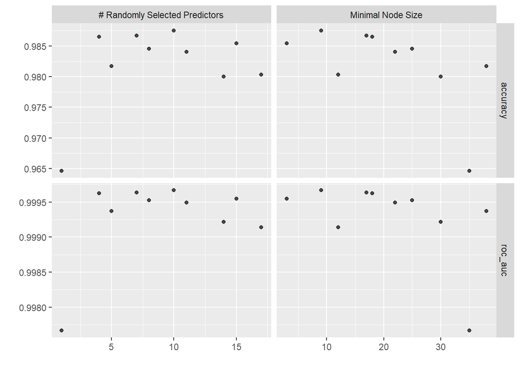

```r
autoplot(ranger_tune)
```

Finalized workflow with best performing parameters

```r
final_rf <- ranger_workflow %>%
  finalize_workflow(select_best(ranger_tune))
final_rf
```

```
## ══ Workflow ════════════════════════════════════════════════════════════════════
## Preprocessor: Recipe
## Model: rand_forest()
##
## ── Preprocessor ────────────────────────────────────────────────────────────────
## 0 Recipe Steps
##
## ── Model ───────────────────────────────────────────────────────────────────────
## Random Forest Model Specification (classification)
##
## Main Arguments:
##   mtry = 10
##   trees = 1000
##   min_n = 9
##
## Computational engine: ranger
```

The function last_fit() fits this finalized random forest one last time to the training data and evaluates one last time on the testing data.

```r
rf_fit <- last_fit(final_rf, data_split)
rf_fit
```

```
## # Resampling results
## # Manual resampling
## # A tibble: 1 × 6
##   splits               id               .metrics .notes   .predicti…¹ .workflow
##   <list>               <chr>            <list>   <list>   <list>      <list>
## 1 <split [14715/4907]> train/test split <tibble> <tibble> <tibble>    <workflow>
## # … with abbreviated variable name ¹.predictions
```

Looking at the metrics of the modeling fit on the testing data. Also, the code below is used for predictions on the testing data.

```r
collect_metrics(rf_fit)
```

```
## # A tibble: 2 × 4
##   .metric  .estimator .estimate .config
##   <chr>    <chr>          <dbl> <chr>
## 1 accuracy multiclass     0.989 Preprocessor1_Model1
## 2 roc_auc  hand_till      1.00  Preprocessor1_Model1
```

```r
# We can use the trained workflow from ikea_fit for prediction, or save it to use later.
predict(rf_fit$.workflow[[1]], testing_d[15, ])
```

```
## # A tibble: 1 × 1
##   .pred_class
##   <fct>
## 1 A
```

```r
# Predicting the classes for the testing data provided from the instructors
predict(rf_fit$.workflow[[1]], testing[20, ])
```

```
## # A tibble: 1 × 1
##   .pred_class
##   <fct>
## 1 B
```

Code below is to examine feature importance. For my model it would appear roll_forearm was an important feature.

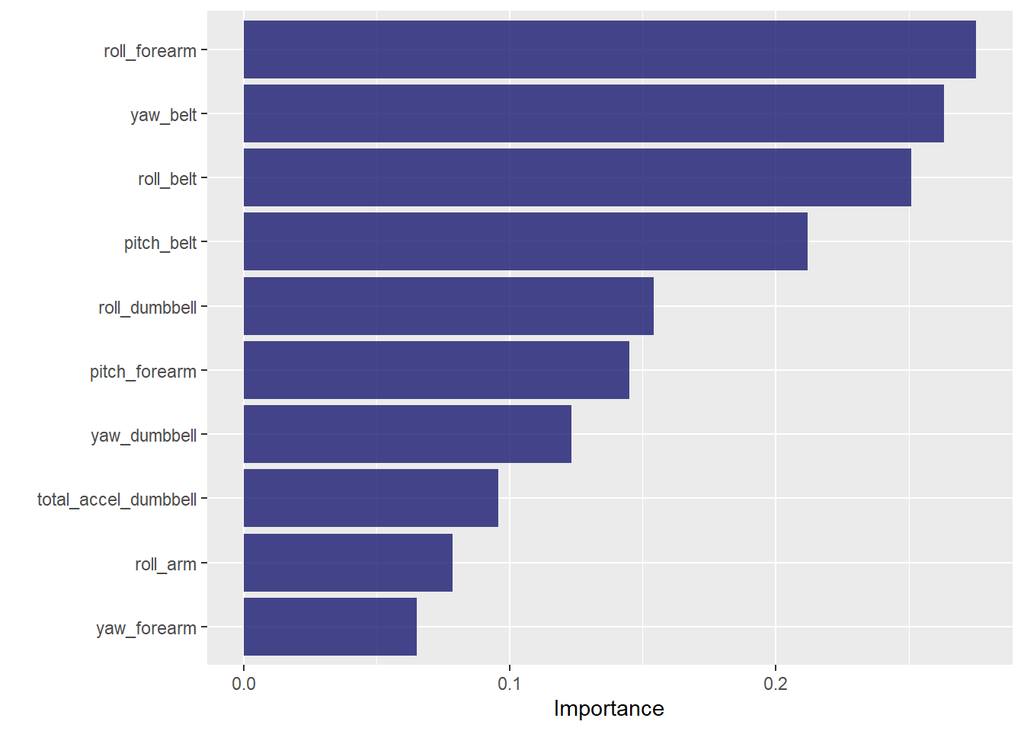

```r
library(vip)
imp_spec <- ranger_spec %>%
  finalize_model(select_best(ranger_tune)) %>%
  set_engine("ranger", importance = "permutation")
workflow() %>%
  add_recipe(ranger_recipe) %>%
  add_model(imp_spec) %>%
  fit(training_d) %>%
  pull_workflow_fit() %>%
  vip(aesthetics = list(alpha = 0.8, fill = "midnightblue"))
```